# data_exploration_2

Collaborator: Eyasped Challa

**Okay, lets look at the data a bit more** Look at distributions of variables

```r
library(tidyverse)
df <- read.csv('cs_1675_fall2021_finalproject.csv')
df <- df %>%
  mutate(x5 = 1 - (x1 + x2 + x3 + x4),
         w = x2 / (x3 + x4),
         z = (x1 + x2) / (x5 + x4),
         t = v1 * v2)
df <- df %>%
  mutate(y = boot::logit(output))
```

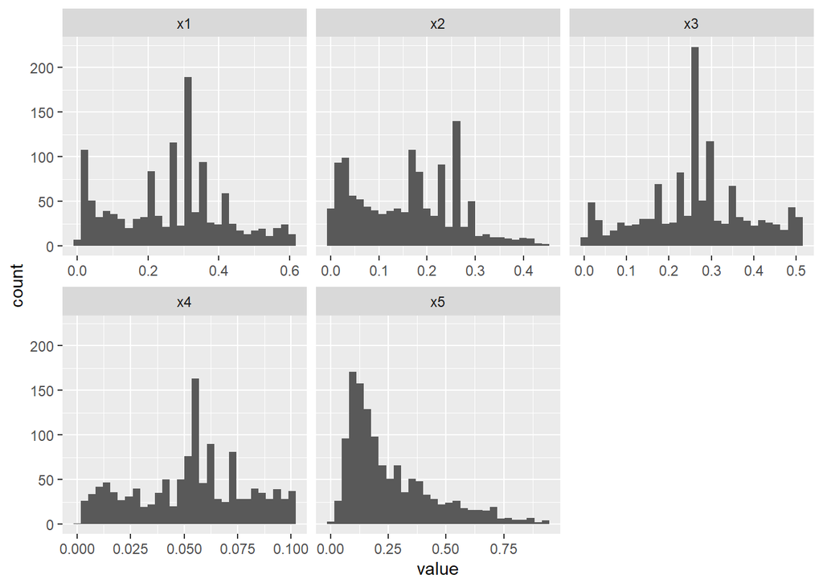

```r
df %>%
  select(starts_with('x'), m) %>%
  tibble::rowid_to_column() %>%
  pivot_longer(starts_with('x')) %>%
  ggplot(mapping = aes(x = value)) +
  geom_histogram(bins = 30) +
  facet_wrap(~name, scales = 'free_x')
```

As with the previous exploration, we see a lot of points around middle values of the Xs.

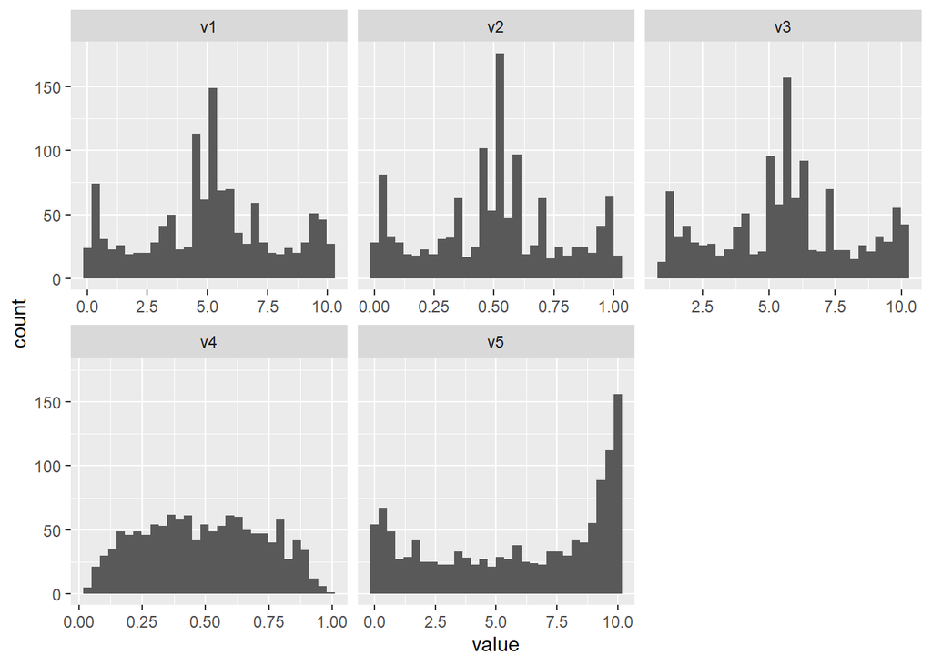

```r
df %>%
  select(starts_with('v'), m) %>%
  tibble::rowid_to_column() %>%
  pivot_longer(starts_with('v')) %>%
  ggplot(mapping = aes(x = value)) +
  geom_histogram(bins = 30) +
  facet_wrap(~name, scales = 'free_x')
```

Similar deal with v1, v2 and v3: wide range of values, but clusters in the middle fo the range. V4 is fat unimodal, v5 has more data towards the extremes.

What about derived features?

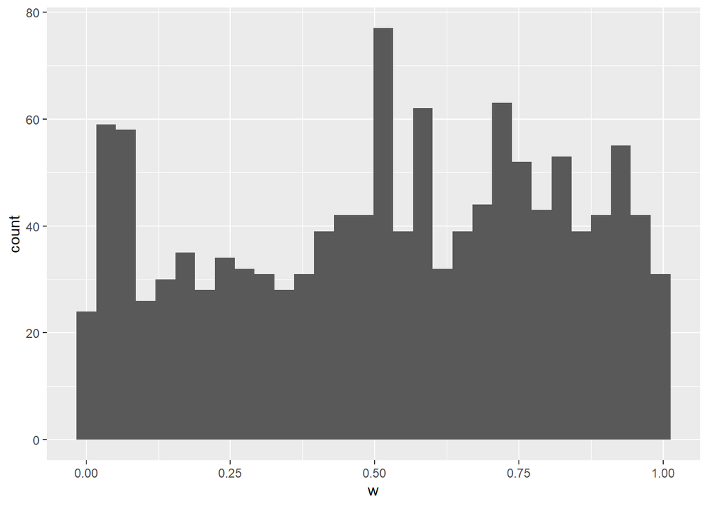

```r
df %>% ggplot(mapping = aes(x = w)) + geom_histogram(bins = 30)
```

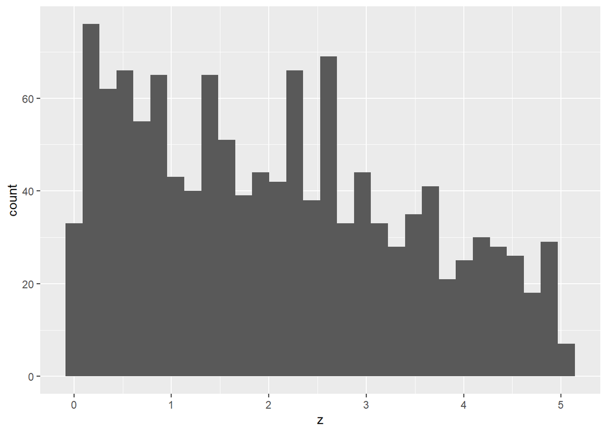

```r
df %>% ggplot(mapping = aes(x = z)) + geom_histogram(bins = 30)
```

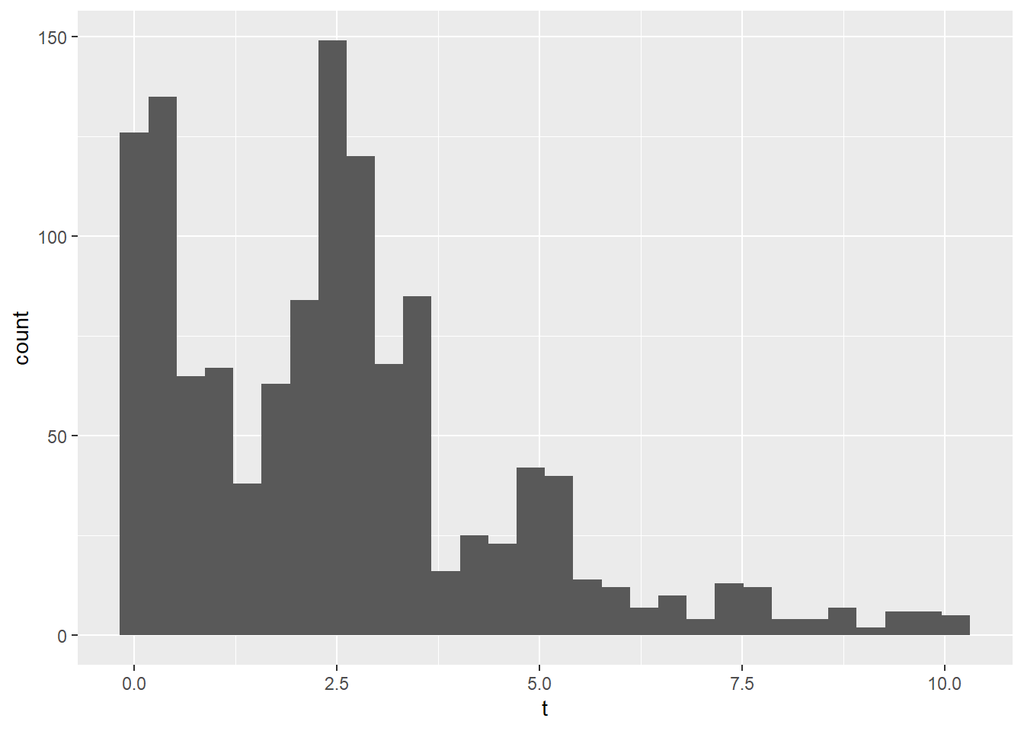

```r
df %>% ggplot(mapping = aes(x = t)) + geom_histogram(bins = 30)
```

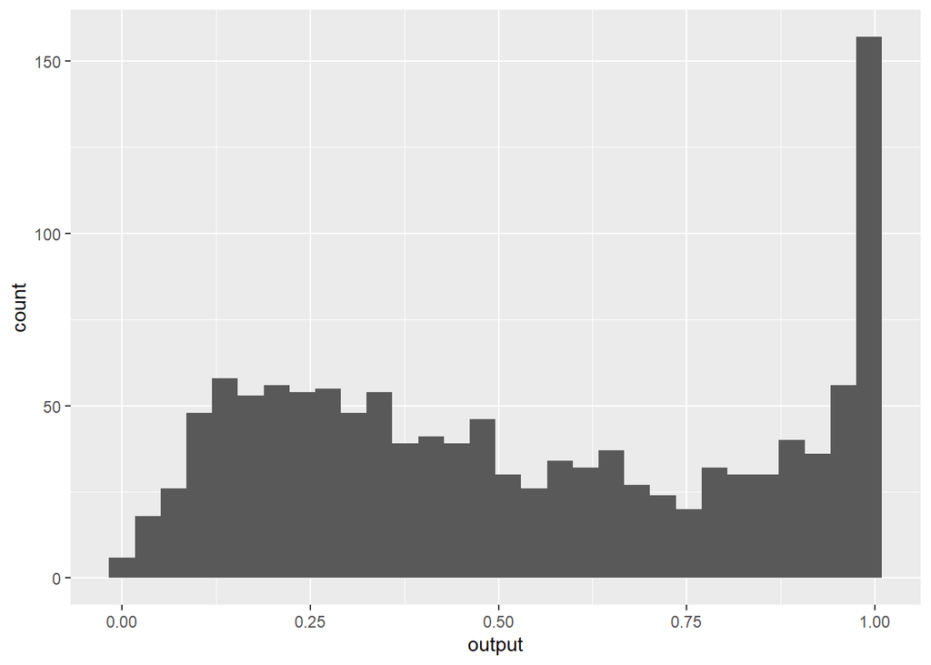

```r
df %>% ggplot(mapping = aes(x = output)) + geom_histogram(bins = 30)
```

Lots of totally corroded samples, but also a mode around .2.

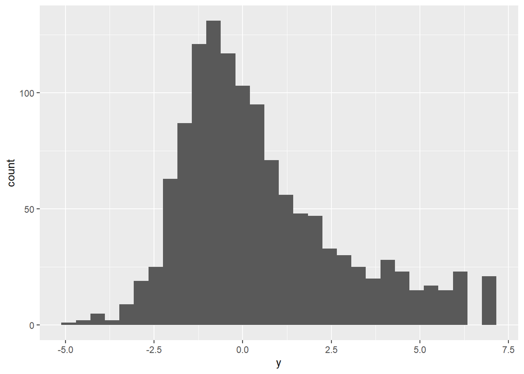

```r
df %>% ggplot(mapping = aes(x = y)) + geom_histogram(bins = 30)
```

The logit-transformed output, Y, looks much nicer than the plain output. It’s unimodal, right-skewed, thanks to those high-corrosion samples

```r
corr_matrix <- df %>% select(!m & !z & !w & !t & !output) %>% cor()
(corr_matrix)
```

```
##              x1            x2           x3            x4           v1
## x1  1.000000000 -0.2768940861 -0.348721875  0.0157839385 -0.006309513
## x2 -0.276894086  1.0000000000  0.360371472  0.0596800237  0.005180593
## x3 -0.348721875  0.3603714724  1.000000000 -0.1172878241 -0.024760272
## x4  0.015783939  0.0596800237 -0.117287824  1.0000000000 -0.001166125
## v1 -0.006309513  0.0051805929 -0.024760272 -0.0011661250  1.000000000
## v2  0.001101446  0.0060983165  0.032539382 -0.0277124279 -0.023331388
## v3  0.007613157 -0.0008629316  0.006032409  0.0094625297  0.049390401
## v4 -0.023374342 -0.1776810363  0.042825445  0.0130650075 -0.043260906
## v5  0.149066493  0.1414083937  0.067631997  0.0004843698  0.087823399
## x5 -0.422264618 -0.5586508604 -0.544271894 -0.1049533412  0.018288904
## y   0.148493615  0.0326065508 -0.072247658 -0.0231085606 -0.047424650
##               v2            v3           v4            v5          x5
## x1  0.0011014458  0.0076131567 -0.023374342  0.1490664929 -0.42226462
## x2  0.0060983165 -0.0008629316 -0.177681036  0.1414083937 -0.55865086
## x3  0.0325393821  0.0060324093  0.042825445  0.0676319972 -0.54427189
## x4 -0.0277124279  0.0094625297  0.013065008  0.0004843698 -0.10495334
## v1 -0.0233313876  0.0493904008 -0.043260906  0.0878233994  0.01828890
## v2  1.0000000000 -0.0009872661 -0.005942516  0.0307615366 -0.02131377
## v3 -0.0009872661  1.0000000000  0.035988892 -0.0829616032 -0.01073678
## v4 -0.0059425164  0.0359888919  1.000000000 -0.0115875301  0.08494689
## v5  0.0307615366 -0.0829616032 -0.011587530  1.0000000000 -0.23797140
## x5 -0.0213137694 -0.0107367813  0.084946889 -0.2379713993  1.00000000
## y   0.0022896378 -0.0367094464 -0.004605700 -0.0149899502 -0.08580464
##               y
## x1  0.148493615
## x2  0.032606551
## x3 -0.072247658
## x4 -0.023108561
## v1 -0.047424650
## v2  0.002289638
## v3 -0.036709446
## v4 -0.004605700
## v5 -0.014989950
## x5 -0.085804641
## y   1.000000000
```

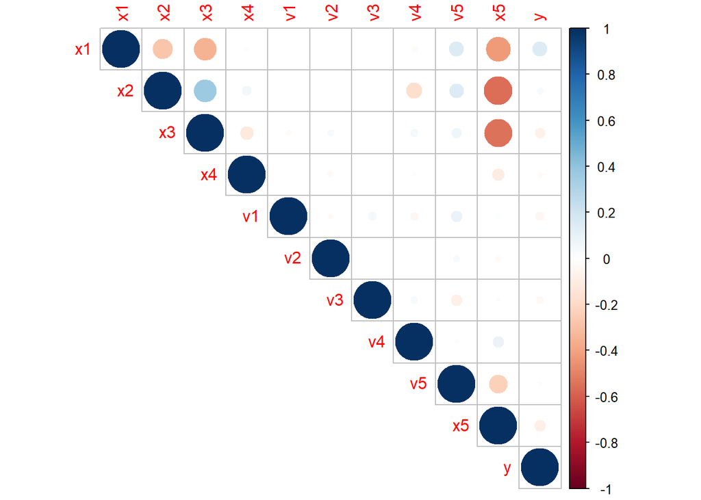

```r
corrplot::corrplot(corr = corr_matrix, type = 'upper')
```

Nothing crazy here. Makes sense that there’s some negative correlation between x inputs, as they’re the ingredients. Strange that x2 and x3 are weakly positively correlated. As exploration 1 suggested, no strong correlations between inputs and y. X5, as expected from its definition, is negatively correlated with other x inputs. But this is good news, since we don’t have to worry much about correlated coefficients.

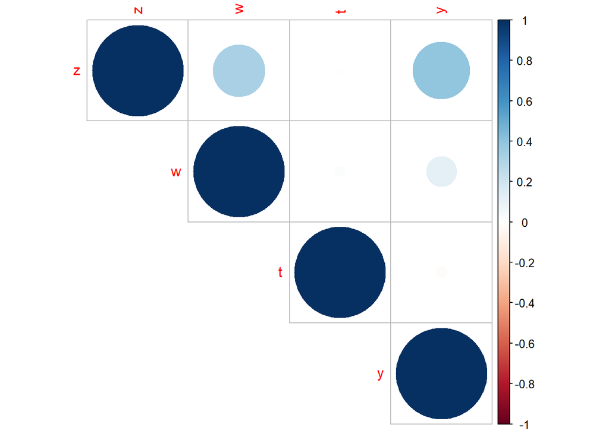

```r
derived_input_corr_matrix <- df %>% select(z | w | t | y) %>% cor()
corrplot::corrplot(corr = derived_input_corr_matrix, type = 'upper')
```

Z and W are correlated, but this is because they both depend on x2 and x4 to some degree. Interestingly, Z and Y have the strongest input - output correlation we’ve seen so far. T has no correlation..